# Tratamiento de series climáticas con R

Victor Hugo Patiño Bravo

Agosto, 2015

# Introducción.

En el presente documento se muestra una breve explicación del funcionamiento de un grupo de scripts o códigos en el software estadístico `R` que permitirán al usuario la depuración, control de calidad y posterior imputación de datos faltantes (*fill gaps*) en series con información climática. Dichos scripts, contemplan 6 variables que son: temperaturas máximas y mínimas, precipitación, humedad relativa, energía solar y brillo solar (horas de luz al día).

Aunque el objetivo es obtener una serie de información a escala diaria, los algoritmos están diseñados para procesar información desde una escala temporal horaria si se tiene, haciendo la respectiva conversión.

Con esta aplicación, no se pretende en ningún momento reemplazar alguna otra herramienta existente, sino por el contrario exponer una serie de pasos consensados y probados para el tratamiento de datos, de una manera sencilla para el usuario como alternativa al tratamiento de datos. A su vez, el usuario podrá modificar lo que considere pertinente, según sus necesidades.

Con el propósito de afianzar lo aquí expuesto, se dispondrá de bases de datos de ejemplo de clima para poner en práctica los conceptos. Los scripts que deberá usar son `FUNCTIONS.R`, `EASY_FUNCTIONS.R` y `GRAPHICS.R`

### Aspectos previos.

Es importante tener en cuenta antes de iniciar con este proceso, que existen unos lineamientos para proceder correctamente con esta etapa del análisis. Dichos lineamientos reposan en el documento `Requerimientos de Clima`.

En él se encuentra detallado cómo deben de ir los archivos de entrada y los archivos auxiliares que son usados en el procedimiento. Una vez cumplido con esto podemos continuar con el control de calidad de los datos climáticos. Por último no olvidar que para ejecutar las líneas de código en `R`, se debe seleccionar o colocar el cursor al final de esta y se puede utilizar las teclas `Ctrl + Enter` o `Ctrl +R`; otra opción es hacer clic en el botón `Run` en la esquina superior derecha de la ventana del código.

### Instalación de paquetes en R.

Para la ejecución de los distintos procesos es necesario que `R` tenga instalados los siguientes paquetes:

```r
install.packages("chron")
install.packages("stringr")
install.packages("tcltk")
install.packages("sirad")
install.packages("randomForest")
install.packages("rpart")
install.packages("tidyr")
install.packages("dplyr")
install.packages("ggplot2")
install.packages("RMAWGEN")
```

La función `install.packages()` permite descargar el paquete especificado entre comillas; este paso solo se realiza la primera vez que se va a utilizar el código o cuando se cambie de versión de R. Para la posterior utilización de los paquetes previamente instalados, se utiliza la función `library()`, la cual los cargará y habilitará para su uso.

### Ejecución de scripts.

Como primer paso, debemos ubicar los scripts `FUNCTIONS.R`, `EASY_FUNCTIONS.R` y `GRAPHICS.R`, junto con los archivos `csv`[^1] auxiliares obtenidos en la preparación previa de los datos en una sola carpeta, que será la que se utilizara para el resto del análisis.

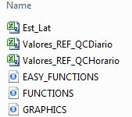

Seguidamente se debe abrir el script `FUNCTIONS.R`, y dar clic en *Source*. De esta manera se cargaran todas las funciones de trabajo contenidas en dicho código. Estas funciones fueron creadas de acuerdo a las necesidades de trabajo:

[figure not shown]

Ahora procedemos a abrir el script `EASY_FUNCTIONS.R`. Aquí encontrará un script subdividido en secciones, señaladas con el símbolo numeral (#); de aquí en adelante se ejecutará sección por sección según las necesidades.

De acuerdo a lo anterior, vamos hasta la sección `#Work directory` y modificaremos la ruta, colocando aquella donde está ubicada la carpeta en la que hemos decidido trabajar. Windows por defecto utiliza el símbolo backslash (\) para especificar rutas de archivos o carpetas; cuando copiemos la ruta desde la barra de direcciones del explorador de Windows, **debemos cambiar** en R el backslash por el símbolo opuesto slash (/) y ejecutamos la línea.

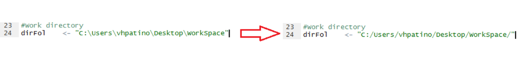

En la siguiente sección de `#Years of analisys` se deben cambiar los valores de los años desde y hasta donde se quiere analizar la información disponible. Una vez fijados los años, ejecutamos esta línea y pasamos a la siguiente etapa `#Create folders`, donde se crearan las carpetas necesarias para guardar los archivos originales a trabajar y los resultados que se vayan obteniendo de estos. Al crear las carpetas, se debe ir hasta el directorio de trabajo seleccionado y organizar los datos originales donde corresponda, dentro de la carpeta `SERIES_ORIGINAL`, separando la información horaria de la diaria.

# Control de Calidad: Datos Horarios.

En varias ocasiones, podemos contar con información de clima a una resolución temporal de minutos (registros cada 5, 10, 20 o 60 minutos); en caso de ser así, en la sección `#Quality Control station hourly` se contempla un proceso de limpieza inicial para estos datos.

En esta fase, se hace el primer contacto con los archivos, por lo que se chequean para ver si estos están bien en cuanto a sus nombres y encabezados internos así como también un reconocimiento de fechas y horas (formatos estandarizados).

El control de calidad contempla el análisis de la información, revisando que estén entre los valores permitidos que han sido ingresados en el archivo de valores de referencia; aquellos valores por fuera del rango son descartados y se muestran en un archivo `ID_VAR_Datos_erroneos.csv`.

Seguidamente se hace una inspección de la presencia de valores repetidos desde dos puntos de vista. Primero se indaga si hay presencia de horas repetidas en una misma fecha, por ejemplo dos o más datos a las 05:35 de la mañana del 25 de abril del 2005. Por otro lado, se rastrea la presencia de valores repetidos de manera secuencial en un día, por ejemplo que el 25 de abril del 2005 tenga un total de 5 veces el valor 27 para temperatura máxima, por lo que el indicador nos arrojará que dicho día presentó un total de 4 valores repetidos. Esto nos servirá primero, para identificar un posible error de descarga de los datos o de digitación o transcripción desde la fuente de origen, pues cuando se repite la misma hora en un mismo día evidentemente hay un fallo, y de otro lado, que haya muchos valores repetidos podría dar cuenta de un error de calibración del instrumento de medida. Sin embargo, en este último paso, puede no necesariamente referirse a un fallo del instrumento, ya que las mediciones registradas cada 5 o 10 minutos pueden no cambiar mucho en temperatura o humedad relativa. Para precipitación solo se tienen en cuenta secuencias de lluvia es decir, no se genera alerta en secuencias de ceros.

Del paso anterior se guardan archivos csv que permitirán comprobar los errores detectados, tanto para los duplicados de horas como para los datos repetidos en un día, esto último sólo si supera el 10 por ciento de los registros que trae dicho día; los reportes quedan bajo los nombres de `ID_VAR_Duplicated.csv` y `ValRep_porcentaje_ID_VAR.csv`. Por último se almacena un archivo de texto donde se han corregido errores de valores fuera de rango y horas repetidas en un mismo día, conservando el nombre original más el sufijo `QC1ready`, y se ha agregado una columna que muestra el tiempo entre registros, que será usada posteriormente para la conversión a datos diarios.

### Conversión a escala diaria.

Como se mencionaba en un principio, el objetivo de estos scripts será entregar un producto o conjunto de series a escala diaria, por lo que la información horaria procesada en el primer control de calidad requiere ser convertida. Esta conversión es posible de realizar en la sección `#Convert`.

Esta etapa toma como datos de entrada, los datos de salida de la etapa anterior por lo que no tendremos que preocuparnos por cómo deben estar estos insumos. El dato diario será posible de obtener siempre y cuando se cumplan con algunas condiciones como:

- Rango horario.
- 80% mínimo de información en el rango horario, según la cantidad de datos por día estimados.
- Cálculo del dato según variable.

Entonces:

| Variable | Rango | Cálculo |
| --- | --- | --- |
| ESOL | DÍA | Acumulado |
| TMAX | DÍA | Valor máximo |
| TMIN | NOCHE | Valor mínimo |
| RAIN | Todo el día | Acumulado |
| RHUM | Todo el día | Promedio |

Después de haber ejecutado esta sección ya se pueden revisar los archivos llevados a escala diaria conservando el nombre original más el sufijo `DailyReady`; con unos archivos adicionales en formato csv, que permiten ver el resumen de la transferencia.

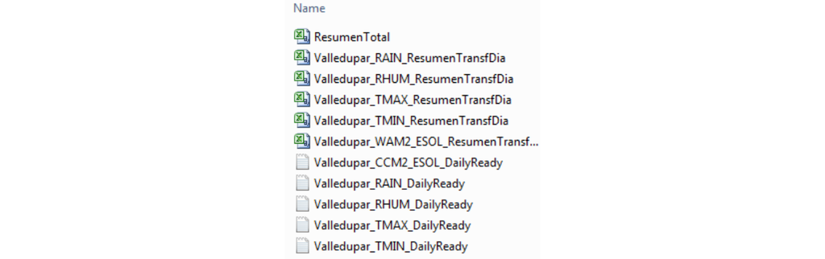

# Control de calidad diario.

Teniendo en cuenta que nuestro objetivo es tener información a una escala temporal diaria, será muy fácil encontrarnos con datos de este tipo, por lo que también se contempla una inspección para los mismos.

En esta fase, se analizaran entonces todos aquellos archivos que vengan desde el origen con datos diarios así como también los ya valorados de origen horario. Ahora se tendrán en cuenta valores de referencia diferentes, puesto que la escala temporal es otra. Al igual que en el control horario, se verifica la correcta especificación de los nombres de los archivos y sus encabezados, lo cual es útil especialmente en la información que originalmente vienen diaria.

En primer instante, se hace un filtro de la serie si esta no posee más de treinta datos reales; en ocasiones se presenta que una supuesta serie viene con información de alrededor de dos o más años y la mayoría de estos datos son ausentes por lo que no haría un aporte relevante así que se descarta. Posteriormente, se identifican fechas repetidas, lo cual es error (no debería pasar en datos diarios), más cuando los valores climáticos son diferentes; dichos errores se suprimen y se calcula una mediana para los datos.

Así mismo, se eliminan valores fuera del rango lógico según los valores de referencia ingresados. Se identifican también valores atípicos, para lo cual se ha establecido un umbral sobre 4 desviaciones estándar, pero dichos valores no son eliminados y se deja a juicio del investigador si estos se deben quitar. Un dato atípico no necesariamente es un dato errado.

Por último se verifica la consistencia entre los valores de temperatura máxima y mínima, donde se comprueba si realmente el valor máximo supera al mínimo. De no ser así, se reporta el hallazgo y se descartan aquellos valores que hayan presentado el problema en un mismo día para una misma estación.

Al final se tendrá reportes diversos de los trabajos realizados y algunas ayudas gráficas del estado de la serie, así como también los archivos de texto limpios de las series, listos para el relleno de información faltante (con el sufijo `ReadyFillGaps`).

# *Inputs u organización de los archivos.*

En este paso se realiza una organización de todos los archivos de una misma variable climática en un único archivo csv, haciendo que estos coincidan por fecha. De esta manera, se obtendrán 5 archivos que se almacenaran en la misma carpeta de salida del paso anterior, puesto que no se modifican de ninguna manera los valores ni tampoco se hace algún proceso de llenado de faltantes.

### *Graphics and Summary: Ayudas gráficas y estadísticas descriptivas.*

A partir de los archivos resultantes del paso anterior se pueden generar una serie de gráficos y estadísticas descriptivas, que ayudaran a tener una idea de cómo quedaron las series para trabajar en la etapa de llenado después de haber pasado por los controles de calidad. Es muy importante este paso, ya que antes del mencionado proceso de imputación, deberemos descartar aquellas series con muchos problemas de faltantes, de lo contrario no será posible tenerlas listas. No hay realmente un punto exacto que indique en qué momento se debe descartar una estación o serie de clima, pero por experiencia se ha podido determinar que con un mínimo de 3 estaciones y que estén presentes a lo sumo un 35 o 40 % de faltantes sería posible trabajar.

**IMPORTANTE**

Se debe tener claro, que a mayor cantidad de datos faltantes nos permitamos trabajar, mayor información estimada se obtendrá. La metodología será mejor a medida que podamos ingresar más información.

Antes de continuar, deberemos asegurarnos de que los archivos csv para las variables de temperatura máxima y mínima, junto con el de precipitación contengan las mismas estaciones.

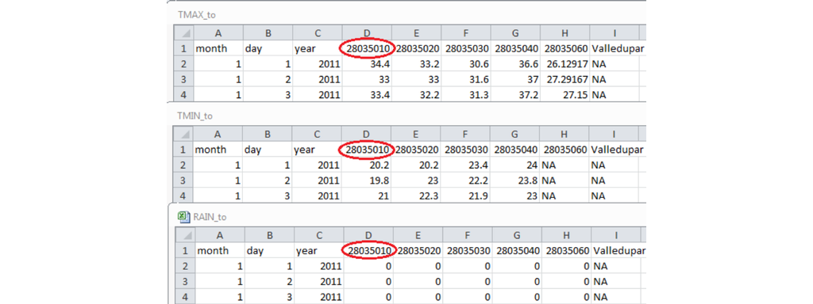

# Generando datos faltantes.

En este punto se empiezan a abordar las metodoloías que contenplam la imputación o relleno de datos que, originalmente no se tenian registrados o que por el proceso de control de calidad fueron descartados. Las variables de Temperatura y Preci[itación serán generados en un primer proceso que trabaja estas variables de manera conjunta y las dos restantes, Humedad Relativa y Energía Solar, serán abordadas por una metodología diferente de manera individual, pero que requiere de las primeras variables libres de NA’s para trabajar.

### GENERATOR_T_R: Generador de datos de Temperatura y Precipitación.

En esta etapa se utilizan una serie de algoritmos para series diarias de clima, desarrollados para la generación de datos faltantes, usando modelos vectoriales auto regresivos “normalizados”. Trabaja bajo el supuesto de que las estaciones ingresadas comparten características similares en cuanto a condiciones climáticas, ya que utiliza dichas similitudes como información de apoyo entre los vacíos que se presenten.

El script para esta labor, fue desarrollado en el Centro de Investigación e Innovación, Fundación Edmund Mach (Fondazione Edmund Mach San Michele all’Adige) en Italia y sus creadores son Emanuele Cordano y Emanuele Eccel[^2]. Originalmente, se generan estimaciones para todo el periodo de interés analizado, pero se modificó para que permitiera conservar los datos originales.

Es posible que después de haber seleccionado las estaciones de trabajo, el código presente errores como:

Error in ecdf(data) : ‘x’ must have 1 or more non-missing values

Este es un error común que implica descartar una o varias estaciones que están muy deficientes como para continuar con el proceso de llenado. Otra opción, sería reducir el periodo de tiempo que se desea analizar (menos años), dado que posiblemente el periodo de datos faltantes es común a todas las estaciones, lo que probablemente ocurre en los extremos de las series [^3]. Si el problema se puede solucionar descartando estaciones, la función `GENERATOR_T_R` tiene un argumento adicional `DontUse=c()`, en el cual se debe(n) especificar la(s) estación(es) a descartar, simplemente colocando el número que indica la posición de esta(s) dentro del archivo de estaciones.

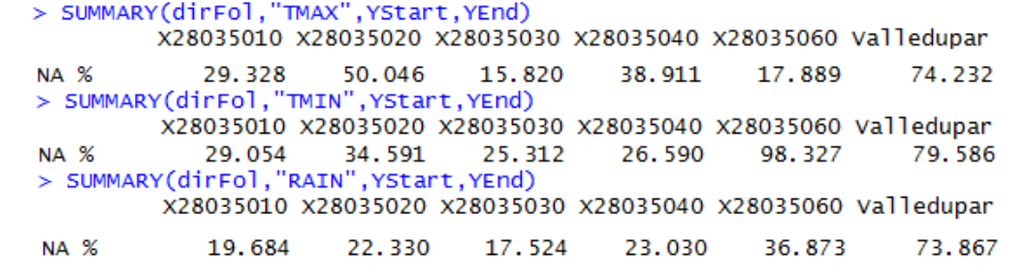

Una sencilla manera de escoger cuál(es) estación(es) descartar, es observando las estadísticas descriptivas y empezar con la más “problemática” según el porcentaje de faltantes o NA’s. Para el ejemplo, la imagen anterior rescata sólo los faltantes presentes en un conjunto de estaciones, para un periodo entre 2007 y 2015, en donde es evidente que la estación Valledupar está en “malas” condiciones para el análisis que se pretende; le sigue la estación 28035060 que para temperatura mínima (TMIN) prácticamente no tiene datos. Dado el ejemplo, supondremos entonces, que se dejaran de lado las estaciones mencionadas que están en las posiciones 5 y 6, entonces el código quedaría:

`>GENERATOR_T_R(dirFol,YStart,YEnd,DontUse=c(5,6))`

## Generador de Humedad relativa y Energía solar.

Las dos funciones siguientes se pueden ejecutar sin problema, teniendo en cuenta que sólo se generará información para las estaciones que hayan quedado en el paso anterior y al mismo tiempo tengan información original para estas dos variables.

Ambas funciones (`GEN_RHUM` y `GEN_ESOL`) trabajan bajo el mismo esquema; se trata de una metodología que tiene como datos de entrada sus propios datos de temperaturas junto con la variable propiamente a estimar (datos originales según sea el caso). Se hace uso de modelos basados en aprendizaje de máquina (Machine Learning), más precisamente con Random Forest, que en términos generales, es una colección de muchos árboles de decisión, técnica que toma los datos originales como conjunto de información de “entrenamiento”, de ellos “aprende” y genera una respuesta promedio para obtener estimaciones lo más precisas posibles.

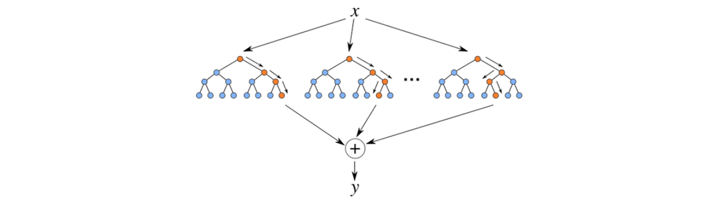

Es una metodología bastante útil cuando se tienen grandes cantidades de datos y cuando las relaciones entre la variable respuesta y explicativas no son lineales.

## Gráficos finales

En la última sección de este código, se pueden generar unas gráficas en las que se mostrará cómo ha quedado la serie resultante, identificando los datos originales (en color rojo) y los que resultaron estimados en el proceso (con color azul), lo que permitirá dar una idea de la calidad de la información.

Así mismo quedan disponibles todos los archivos de texto de las series terminadas identificadas como ID_VAR_FUS. El sufijo FUS hace referencia a que la serie conserva datos originales y estimados, mientras que los que terminan en el sufijo EST, son datos completamente estimados.

# Enlaces de Interés:

- ftp://ftp.fao.org/docrep/fao/009/x0490s/x0490s01.pdf
- https://cran.r-project.org/web/packages/RMAWGEN/index.html
[^1]: Extensión de archivos tipo hoja de cálculo que se puede generar desde Excel.
[^2]: http://presentations.copernicus.org/EGU2012-14026_presentation.pdf
[^3]: Puede suceder cuando la mayoría de las estaciones empezaron o dejaron de registrar en fechas similares, diferentes a las fechas de interés.